# Introduction to StatComp21055

兰敬国 SA21229031

2021-12-23

## Overview

**StatComp21055** 是统计计算课程的期末`R`包。 它主要包括包括三个部分:

- 首先是关于shapes data 的一些统计量的计算，包括均值计算、回归估计和模型选择(决定系数$R^2$)。
- 第二是几个有关变量选择的一些批量化处理函数，方便平时跑模拟。大致分为3个部分: 数据生成，指标计算和画图输出。
- 第三是平时作业汇总(见`homework.html`)

## shapes data

shapes data就是形状数据。比如大脑某些结构的形状, 比较常用的表示方式是坐标法, 在轮廓边缘取一些点来刻画形状(landmark法)。

我们想研究的是响应变量是shape data的情景下, 把欧氏空间的一些方法推广过来。 比如对一组大脑患有疾病的患者,我们想研究大脑某个部位的形状与患者的性别、年龄、病情是否有关，以此确定该疾病是否会影响大脑的某个部位，进而制定相应策略医治。

我们通过两张图来加深了解:

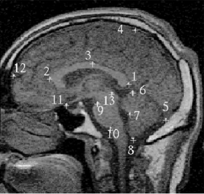

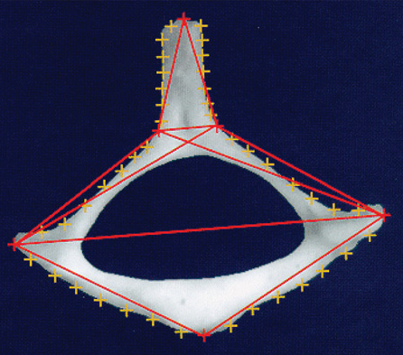

### 算法步骤:

- $\bar{X}=n^{-1} \sum_{i=1}^{n} X_{i}$ , $\hat{\Sigma}=n^{-1} \sum_{i=1}^{n}\left(X_{i}-\bar{X}\right)\left(X_{i}-\bar{X}\right)^{T}$,
- $s_{i n}(x):=1+\left(X_{i}-\bar{X}\right)^{T} \hat{\Sigma}^{-1}(x-\bar{X})$
- $M_{n}(\cdot, x)=n^{-1} \sum_{i=1}^{n} s_{i n}(x) d^{2}\left(Y_{i}, \omega\right)$.
- $\hat{m}_{\oplus}(x)=\underset{\omega \in \Omega}{\operatorname{argmin}} M_{n}(\omega, x)$

brains 数据集

- 形状数据: brains$x 24*3*58
- 年龄: brains$age
- 性别: brains$sex (1 for male / 2 for female)
- 组别: brains$grp

```r
library(StatComp21055)
library(bestsubset)
library(BB)
library(glmnet)
library(shapes)
library(frechet)
data("brains")
## 以年龄、性别和组别作为预测变量
X=cbind(brains$age,brains$grp,brains$sex)[1:10,]
Y=brains$x[,,1:10]
## 预览一下shapes data 的样子
print(Y[,,1])
```

```
##       [,1] [,2] [,3]
##  [1,]   80 23.5   59
##  [2,]   69 18.5   73
##  [3,]   68 19.5   63
##  [4,]   95 48.5   51
##  [5,]   97 45.5   61
##  [6,]   98 43.5   67
##  [7,]   86 61.5   91
##  [8,]   92 34.5   49
##  [9,]   66 46.5   83
## [10,]   66 42.5   37
## [11,]   68 31.5   94
## [12,]   69 18.5   78
## [13,]   55 20.5   58
## [14,]   65 18.5   77
## [15,]   63 18.5   66
## [16,]   41 46.5   47
## [17,]   35 45.5   53
## [18,]   35 40.5   64
## [19,]   46 60.5   88
## [20,]   40 31.5   51
## [21,]   65 44.5   86
## [22,]   63 42.5   35
## [23,]   64 31.5   95
## [24,]   64 18.5   80
```

### 计算一下均值

```r
Fm=Fmean(Y)
Fm
```

```
##           [,1]     [,2]     [,3]
##  [1,] 77.95930 27.16843 61.73238
##  [2,] 66.59319 23.86436 74.58517
##  [3,] 66.57467 23.20933 65.50242
##  [4,] 90.60380 54.38759 48.05084
##  [5,] 94.37873 52.66132 55.99395
##  [6,] 95.99074 50.83840 64.27690
##  [7,] 87.52588 70.62805 87.35683
##  [8,] 89.55561 39.56270 49.32377
##  [9,] 65.35925 56.68658 84.99198
## [10,] 63.40072 48.45568 36.25782
## [11,] 66.49587 43.54147 98.36996
## [12,] 66.86656 26.83772 83.37686
## [13,] 50.12583 26.83323 62.76042
## [14,] 60.81293 24.81068 77.30652
## [15,] 60.59260 23.34109 67.93050
## [16,] 35.34878 54.50689 50.04849
## [17,] 32.45477 51.99939 56.38213
## [18,] 32.75101 50.39036 65.75819
## [19,] 39.44420 71.27715 87.13116
## [20,] 37.36723 39.99944 51.18100
## [21,] 63.34218 55.06467 85.29719
## [22,] 61.00315 48.86261 35.19115
## [23,] 60.61861 43.41920 98.46526
## [24,] 60.63412 25.75398 83.52928
```

### 回归估计

```r
## 预测一下自变量是X[1,]处的Y值
yhat=FREShape(Y,X,X[1,])

cbind(Y[,,1],yhat)
```

```
##       [,1] [,2] [,3]     [,4]     [,5]     [,6]
##  [1,]   80 23.5   59 79.28772 28.25237 60.57748
##  [2,]   69 18.5   73 66.51428 24.47849 74.99500
##  [3,]   68 19.5   63 66.43632 24.07128 66.01625
##  [4,]   95 48.5   51 92.67381 53.40821 49.00932
##  [5,]   97 45.5   61 94.26174 51.79255 57.12669
##  [6,]   98 43.5   67 95.96899 50.23292 65.85457
##  [7,]   86 61.5   91 86.33949 71.81468 87.24627
##  [8,]   92 34.5   49 89.49049 39.92399 49.26563
##  [9,]   66 46.5   83 65.83559 57.23068 85.08875
## [10,]   66 42.5   37 63.22134 49.19305 35.53090
## [11,]   68 31.5   94 66.21061 42.93926 96.42460
## [12,]   69 18.5   78 67.68401 26.62084 82.83224
## [13,]   55 20.5   58 49.83766 26.91196 62.17280
## [14,]   65 18.5   77 61.21212 24.77235 78.60420
## [15,]   63 18.5   66 59.93923 23.23056 68.63002
## [16,]   41 46.5   47 34.88847 54.11105 50.59359
## [17,]   35 45.5   53 31.52754 52.15763 56.92642
## [18,]   35 40.5   64 33.11375 50.52988 67.11565
## [19,]   46 60.5   88 39.37169 72.19224 86.26190
## [20,]   40 31.5   51 36.39543 40.09221 51.20312
## [21,]   65 44.5   86 63.90219 54.40254 85.36255
## [22,]   63 42.5   35 59.96226 47.89982 34.20438
## [23,]   64 31.5   95 61.08346 42.66579 97.20333
## [24,]   64 18.5   80 60.64047 25.17464 82.55320
```

### 模型估计

针对不同的预测变量我们可以建立不同的模型，所以需要有个指标衡量哪个模型更好。能从欧氏空间借鉴的是决定系数($R^2$)或者调整后的决定系数($adj-R^2$)。决定系数越大说明模型拟合效果越好。

- 欧式空间: $R^{2}=1-\frac{\operatorname{Var}\left(Y-\beta_{0}^{*}-\left(\beta_{1}^{*}\right)^{T}(X-\mu)\right)}{\operatorname{Var}(Y)}$
- Shapes 空间: $R_{\oplus}^{2}:=1-\frac{E\left[d^{2}\left(Y, m_{\oplus}(X)\right)\right]}{V_{\oplus}}$
- $\hat{R}_{\oplus}^{2}=1-\frac{\sum_{i=1}^{n} d^{2}\left(Y_{i}, \hat{m}_{\oplus}\left(X_{i}\right)\right)}{\sum_{i=1}^{n} d^{2}\left(Y_{i}, \hat{\omega}_{\oplus}\right)}$
- 调整R方: $\hat{R}_{\oplus, \mathrm{adj}}^{2}(\mathcal{M})=\hat{R}_{\oplus}^{2}-\left(1-\hat{R}_{\oplus}^{2}\right) \frac{q}{n-q-1}$
- 模型选择: $q^{*}=\underset{1 \leq q \leq p}{\operatorname{argmax}} \max _{\mathcal{M} \in \mathcal{C}_{q}} \hat{R}_{\oplus, \text { adj }}^{2}(\mathcal{M})$

```r
r2=R2(Y,X)
r2
```

```
## $R2
## [1] 0.4053331
##
## $R2.adj
## [1] 0.1079997
```

## 变量选择

这部分主要是变量选择的批处理函数的使用。

### 生成模拟数据

```r
n=30
p=8
support.size=5
dat=sim.data(n,p,support.size)
dat
```

```
## $x
##                x1          x2           x3          x4          x5          x6
##  [1,] -0.62645381  1.35867955  2.401617761 -0.54252003 -0.50595746  0.45018710
##  [2,]  0.18364332 -0.10278773 -0.039240003  1.20786781  1.34303883 -0.01855983
##  [3,] -0.83562861  0.38767161  0.689739362  1.16040262 -0.21457941 -0.31806837
##  [4,]  1.59528080 -0.05380504  0.028002159  0.70021365 -0.17955653 -0.92936215
##  [5,]  0.32950777 -1.37705956 -0.743273209  1.58683345 -0.10019074 -1.48746031
##  [6,] -0.82046838 -0.41499456  0.188792300  0.55848643  0.71266631 -1.07519230
##  [7,]  0.48742905 -0.39428995 -1.804958629 -1.27659221 -0.07356440  1.00002880
##  [8,]  0.73832471 -0.05931340  1.465554862 -0.57326541 -0.03763417 -0.62126669
##  [9,]  0.57578135  1.10002537  0.153253338 -1.22461261 -0.68166048 -1.38442685
## [10,] -0.30538839  0.76317575  2.172611670 -0.47340064 -0.32427027  1.86929062
## [11,]  1.51178117 -0.16452360  0.475509529 -0.62036668  0.06016044  0.42510038
## [12,]  0.38984324 -0.25336168 -0.709946431  0.04211587 -0.58889449 -0.23864710
## [13,] -0.62124058  0.69696338  0.610726353 -0.91092165  0.53149619  1.05848305
```

[output cut: 85 more lines]

### 生成数据 计算一些常用指标 并保存

变量选择有很多中算法。比如: Lasso`、Relaxed lasso、Forward stepwise、MCP、L0Learn、abess等等。

不过不同的算法基本是不同作者提出的，他们各自写R包，函数的输入参数、输出样式可能会不一样。我通过增加中间转换函数，把它们的输入输出格式调整成一致。同时计算了一些指标，衡量不同算法的指标。

- Relative risk
- Relative test error: 预期的测试误差/Bayes 误差
- F-score(综合查全率与查准率，衡量模型选择准确程度)
- Proportion of variance explained(可解释方差所占比例，越大越好)
- Number of nonzeros(非零系数个数，用于与真实情形比较)

```r
methods=c("Lasso","Forward stepwise","Relaxed lasso")
rho.vec =c(0.35)
beta.type = 1
snr.vec = exp(seq(log(0.05),log(6),length=5))
file.list=compute.index(n,p,nval=5,methods = methods,file=NULL,rho.vec=rho.vec,snr.vec=snr.vec,beta.type = beta.type)
```

```
## ..... NEW SIMULATION .....
## --------------------------
## File: rd/sim.n30.p8.beta1.rho0.35.snr0.05.rds
##
##
## ..... NEW SIMULATION .....
## --------------------------
## File: rd/sim.n30.p8.beta1.rho0.35.snr0.17.rds
##
##
## ..... NEW SIMULATION .....
## --------------------------
## File: rd/sim.n30.p8.beta1.rho0.35.snr0.55.rds
##
##
## ..... NEW SIMULATION .....
## --------------------------
## File: rd/sim.n30.p8.beta1.rho0.35.snr1.81.rds
##
##
## ..... NEW SIMULATION .....
## --------------------------
## File: rd/sim.n30.p8.beta1.rho0.35.snr6.rds
```

### 画图输出

可以指定要比较的算法和要比较的指标，同时可以选择是否输出pdf。

#### risk

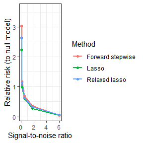

```r
library(ggplot2)
method.nums = c(1,2,3)

rho = 0.35

## risk
plot_index(file.list, what="risk",method.nums=c(1,2,3), method.names=methods,
               make.pdf=FALSE,fig.dir=NULL,file.name="risk", h=4, w=4)
```

#### error

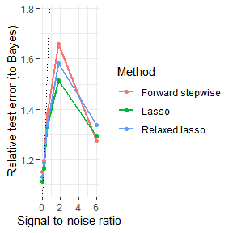

```r
plot_index(file.list, what="error",method.nums=c(1,2,3), method.names=methods,
               make.pdf=FALSE,fig.dir=".",file.name="error", h=4, w=4)
```

#### nonzero

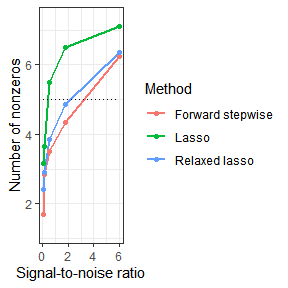

```r
plot_index(file.list, what="nonzero",method.nums=c(1,2,3), method.names=methods,
               make.pdf=FALSE,fig.dir=".",file.name="nonzero", h=4, w=4)
```

#### F

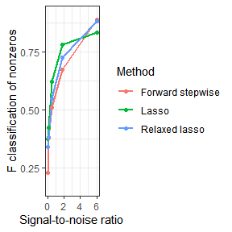

```r
plot_index(file.list, what="F",method.nums=c(1,2,3), method.names=methods,
               make.pdf=FALSE,fig.dir=".",file.name="F", h=4, w=4)
```

#### Prop

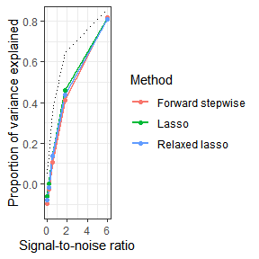

```r
plot_index(file.list, what="prop",method.nums=c(1,2,3), method.names=methods,
               make.pdf=FALSE,fig.dir=".",file.name="prop", h=4, w=4)
```

## Rcpp程序与R程序比较

考虑二元随机变量$X=(X_1,X_2)$, 密度函数:
$$f(x, y) \propto\left(\begin{array}{l}
n \\
x
\end{array}\right) y^{x+a-1}(1-y)^{n-x+b-1}, \quad x=0,1, \ldots, n, 0 \leq y \leq 1$$

用Gibbs采样法分别在`R`与`C`中运行, 比较一下效率

### GibbsR

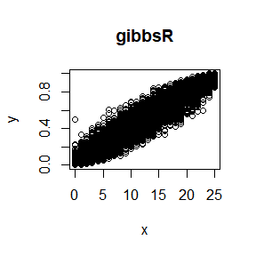

```r
a=1
b=1
n=25
N=10000

X=gibbsR(a,b,n,N)
plot(X[,1],X[,2],xlab = "x",ylab = "y",main = "gibbsR")
```

### GibbsC

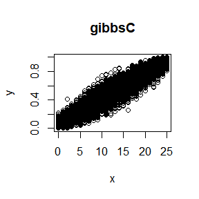

```r
Xc=gibbsC(a,b,n,N)
plot(Xc[,1],Xc[,2],xlab = "x",ylab = "y",main="gibbsC")
```

用`qqplot`比较一下产生的随机变量是否一致

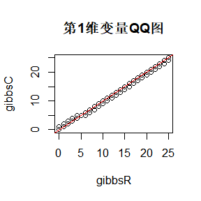

```r
qqplot(X[,1],Xc[,1],xlab = "gibbsR",ylab = "gibbsC",main="第1维变量QQ图")
abline(0,1,col = "red")
```

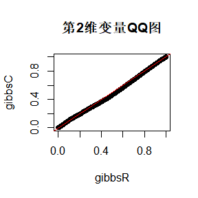

```r
qqplot(X[,2],Xc[,2], xlab = "gibbsR",ylab = "gibbsC",main="第2维变量QQ图")
abline(0,1,col = "red")
```

比较运行时间

```r
library(microbenchmark)
ts=microbenchmark(gibbR=gibbsR(a,b,n,N), gibbC=gibbsC(a,b,n,N))
summary(ts)[,c(1,3,5,6)]
```

```
##    expr       lq  median        uq
## 1 gibbR 57.76255 76.3535 116.05610
## 2 gibbC  5.59445  8.0826   9.78635
```